# GAM_Brain_Activity

Thomas Wolff

2025-01-14

### Bringing brain activity data into R Studio

```r
library(gamair)
library(mgcv)
data(brain)
```

## Removing outliers from the medFPQ faeture and modeling with Gaussian model

The plots indicate the model residuals are not Gaussian and that some transformation needs to occur.

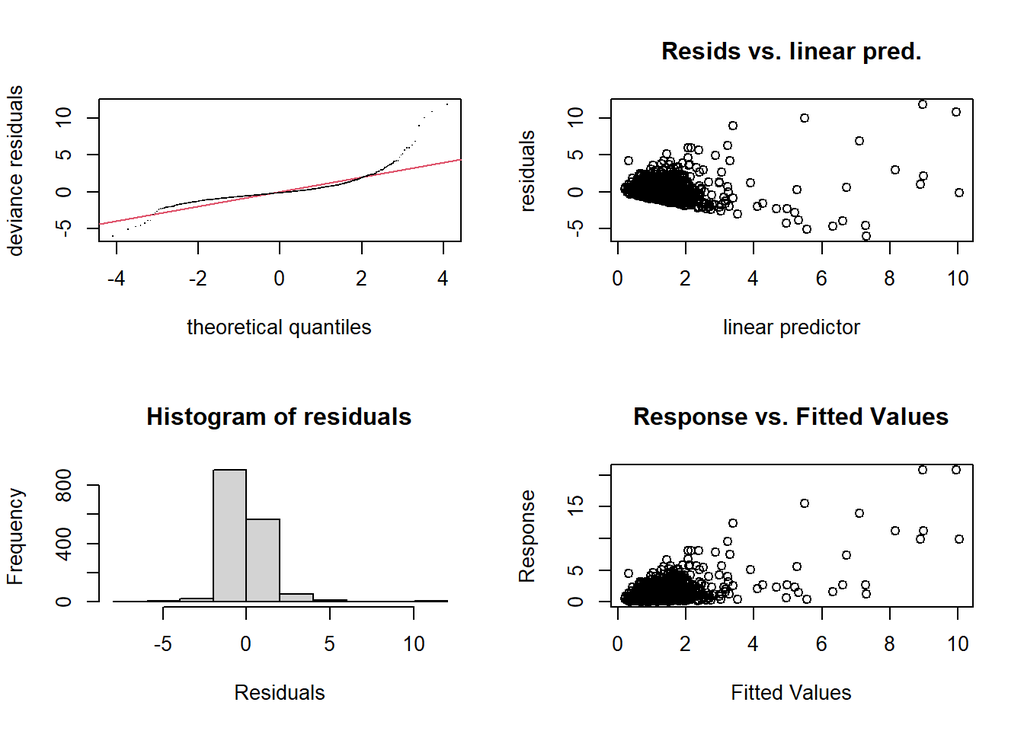

```
##
## Method: GCV   Optimizer: magic
## Smoothing parameter selection converged after 6 iterations.
## The RMS GCV score gradient at convergence was 5.724028e-05 .
## The Hessian was positive definite.
## Model rank =  100 / 100
##
## Basis dimension (k) checking results. Low p-value (k-index<1) may
## indicate that k is too low, especially if edf is close to k'.
##
##          k'  edf k-index p-value
## s(Y,X) 99.0 86.8    0.86  <2e-16 ***
## ---
## Signif. codes:  0 '***' 0.001 '**' 0.01 '*' 0.05 '.' 0.1 ' ' 1
```

```r
brain <- brain[brain$medFPQ >= 3e-5,]

m0 <- gam(medFPQ~s(Y,X,k=100), data=brain)
gam.check(m0)
```

We can assume that the variance of y is proportional to mu raised to some power Beta where Beta is a parameter that we can estimate with regression

So we take the log of the squared residuals and regress using the fitted values

To find the value of Beta which is equal to 1.919 (2)

```r
e <- residuals(m0); fv <- fitted(m0)
lm(log(e^2)~log(fv))
```

```
##
## Call:
## lm(formula = log(e^2) ~ log(fv))
##
## Coefficients:
## (Intercept)      log(fv)
##      -1.959        1.919
```

### Second model fit using a 4th-root transform on the response variable

This transform fixes a lot of the issues with the residuals and the fitted values

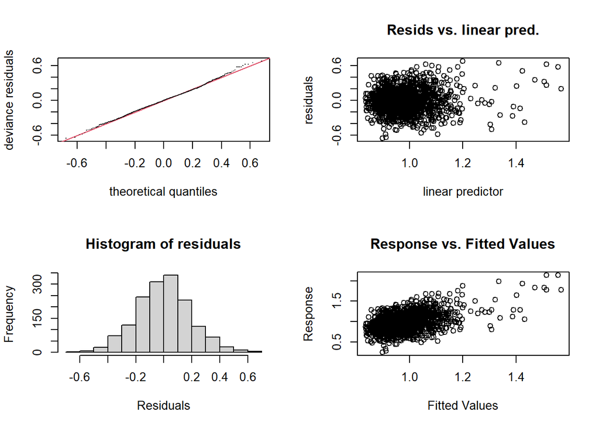

```
##
## Method: GCV   Optimizer: magic
## Smoothing parameter selection converged after 4 iterations.
## The RMS GCV score gradient at convergence was 4.547356e-06 .
## The Hessian was positive definite.
## Model rank =  100 / 100
##
## Basis dimension (k) checking results. Low p-value (k-index<1) may
## indicate that k is too low, especially if edf is close to k'.
##
##          k'  edf k-index p-value
## s(Y,X) 99.0 64.2    0.92  <2e-16 ***
## ---
## Signif. codes:  0 '***' 0.001 '**' 0.01 '*' 0.05 '.' 0.1 ' ' 1
```

```r
m1 <- gam(medFPQ^0.25~s(Y,X,k=100), data=brain)
gam.check(m1)
```

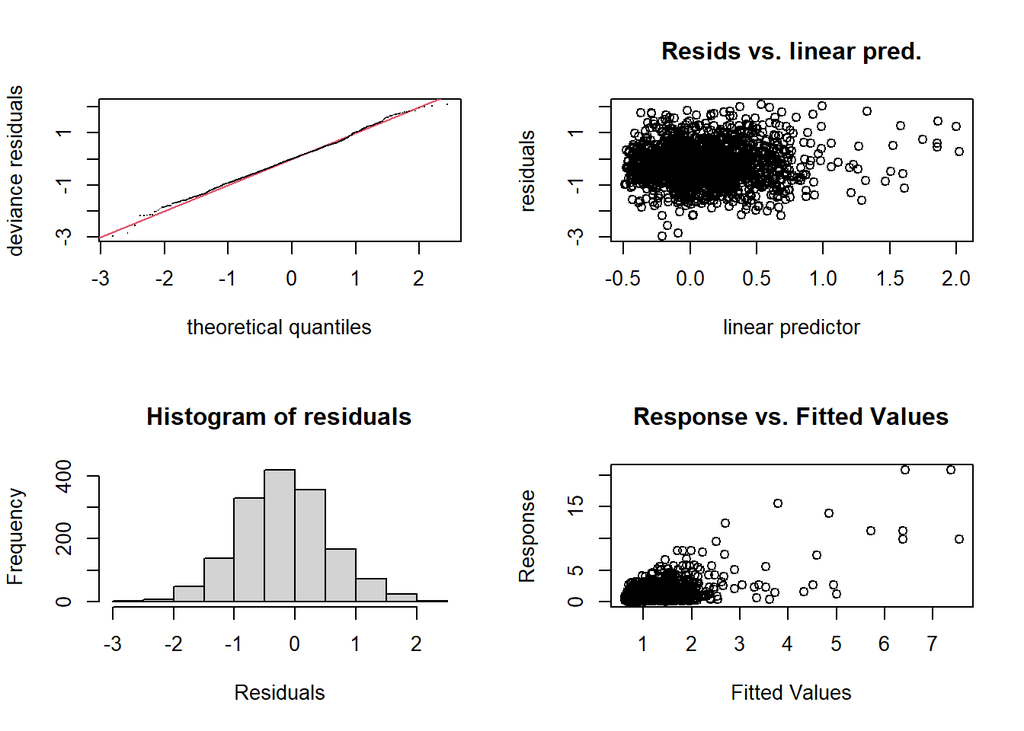

```
##
## Method: GCV   Optimizer: outer newton
## full convergence after 3 iterations.
## Gradient range [8.254059e-10,8.254059e-10]
## (score 0.6273935 & scale 0.57966).
## Hessian positive definite, eigenvalue range [0.006626702,0.006626702].
## Model rank =  100 / 100
##
## Basis dimension (k) checking results. Low p-value (k-index<1) may
## indicate that k is too low, especially if edf is close to k'.
##
##          k'  edf k-index p-value
## s(Y,X) 99.0 60.2    0.88  <2e-16 ***
## ---
## Signif. codes:  0 '***' 0.001 '**' 0.01 '*' 0.05 '.' 0.1 ' ' 1
```

```r
m2 <- gam(medFPQ~s(Y,X,k=100), data=brain, family=Gamma(link=log))
gam.check(m2)
```

```r
mean(fitted(m1)^4)
```

```
## [1] 0.9838708
```

```r
mean(fitted(m2));(mean(brain$medFPQ))
```

```
## [1] 1.21056
```

```
## [1] 1.249506
```

### Plotting the brain activity using contour plot

This works well, but this model has many degrees of freedom, and is therefore too complex.

Using and additive model may work better.

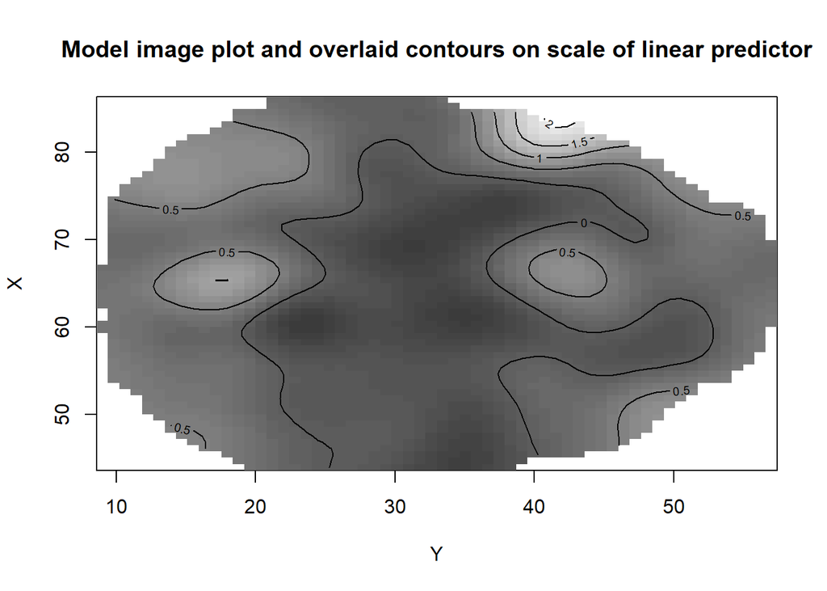

```r
plot <- function(model) {
  vis.gam(model, plot.type = "contour", too.far=0.03,
          color="gray", n.grid=60, zlim=c(-1,2),
          main=paste0("Model image plot and overlaid contours on scale of linear predictor"))
}

plot(m2)
```

### Here we try and additive model to simplify the model and reduce degrees of freedom

Where: log(E[medFPQi]) = f1(Yi) + f2(Xi) where medFPQ ~ Gamma

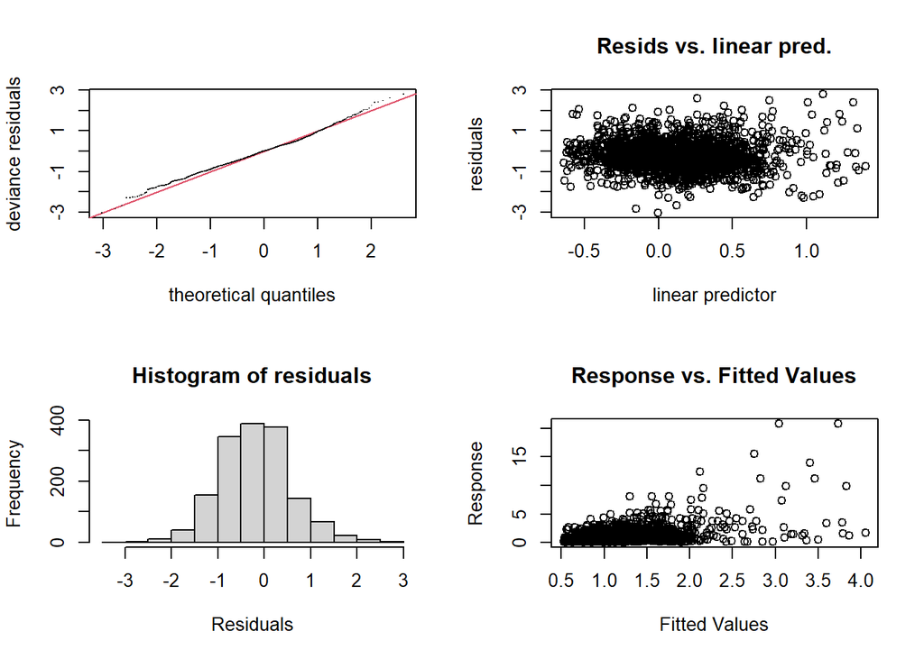

```
##
## Method: GCV   Optimizer: outer newton
## full convergence after 4 iterations.
## Gradient range [1.043818e-08,7.159901e-08]
## (score 0.6509696 & scale 0.6679285).
## Hessian positive definite, eigenvalue range [0.001035473,0.001361742].
## Model rank =  59 / 59
##
## Basis dimension (k) checking results. Low p-value (k-index<1) may
## indicate that k is too low, especially if edf is close to k'.
##
##        k'  edf k-index p-value
## s(Y) 29.0  9.6    0.82  <2e-16 ***
## s(X) 29.0 20.2    0.82  <2e-16 ***
## ---
## Signif. codes:  0 '***' 0.001 '**' 0.01 '*' 0.05 '.' 0.1 ' ' 1
```

```r
m3 <- gam(medFPQ~s(Y,k=30) + s(X, k=30), data=brain, family=Gamma(link=log))

gam.check(m3)
```

### New model with isotropic interaction term s(Y,X,k=100) added as a smoothing parameter.

```r
m4 <- gam(medFPQ~s(Y,k=30) + s(X,k=30) + s(Y,X,k=100), data=brain, family=Gamma(link=log))

anova(m3,m4,test="F")
```

```
## Analysis of Deviance Table
##
## Model 1: medFPQ ~ s(Y, k = 30) + s(X, k = 30)
## Model 2: medFPQ ~ s(Y, k = 30) + s(X, k = 30) + s(Y, X, k = 100)
##   Resid. Df Resid. Dev     Df Deviance      F    Pr(>F)
## 1    1528.1     979.01
## 2    1477.7     893.07 50.387   85.944 3.0418 1.457e-11 ***
## ---
## Signif. codes:  0 '***' 0.001 '**' 0.01 '*' 0.05 '.' 0.1 ' ' 1
```

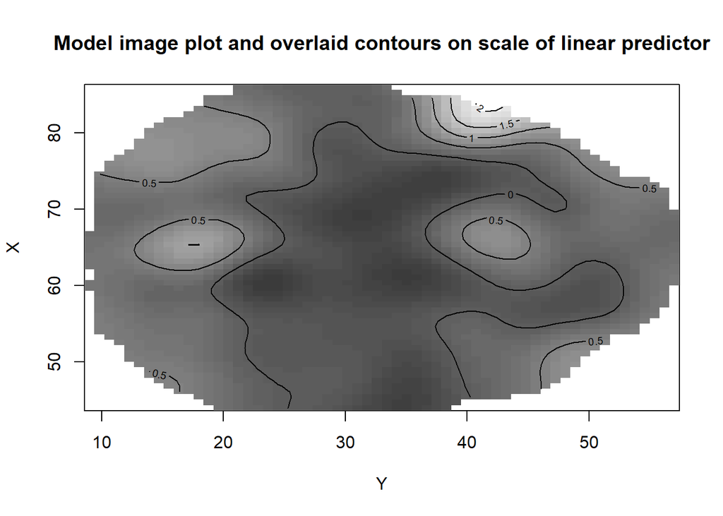

```r
plot(m2)
```

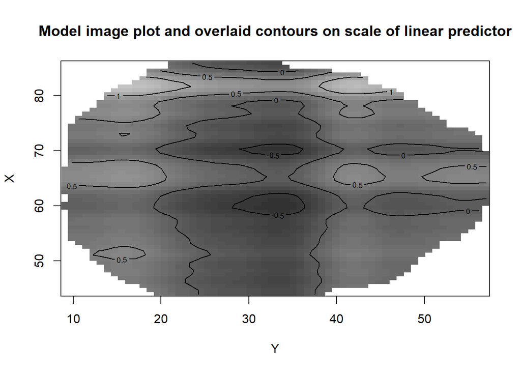

```r
plot(m3)
```

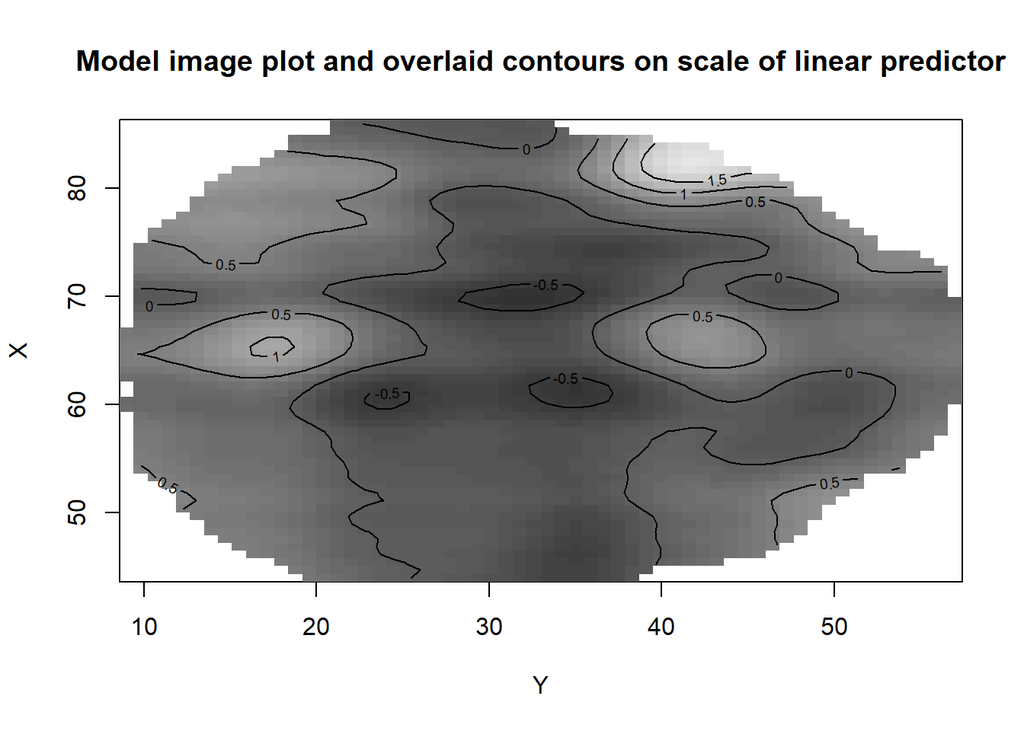

```r
plot(m4)
```

### Tensor product smooths

It is worth checking whether tensor product smooths are better than isotropic product smooths

Tensor products are scale invariant and are computationally efficient

tm is a Tensor product of two cubic regression spline bases, rank 10 * rank 10 = rank 100

tm1 is a purely additive model with two rank 10 cubic regression splines so tm1 is nested within tm

```r
## Tensor product on the interaction non-additive model
tm <- gam(medFPQ~te(Y,X,k=10), data=brain, family=Gamma(link=log))

tm1 <- gam(medFPQ~s(Y,k=10,bs="cr") + s(X,bs="cr",k=10), data=brain, family=Gamma(link=log))
```